# Avaliação 3 - Valor: 34 pontos

Introdução à Ciência de Dados - 2025  
Bacharelado em Administração

Autores

Pedro Silva Gomides

Thiago Augusto Silva Vital

Weverton de Oliveira Rodrigues

Data de Publicação

9 de julho de 2025

## Questão 1

### Inferência sobre Proporções Populacionais

**a)**

```r
# Dados da pesquisa

n_A <- 350
x_A <- 273
n_B <- 290
x_B <- 198
```

```r
# Estimativa pontual da proporção de clientes satisfeitos do grupo A
p_hat_A <- x_A / n_A
p_hat_A
```

```
[1] 0.78
```

```r
# Estimativa pontual da proporção de clientes satisfeitos do grupo B
p_hat_B <- x_B / n_B
p_hat_B
```

```
[1] 0.683
```

```r
# Estimativa pontual da diferença entre as proporções
diff_hat <- p_hat_A - p_hat_B
diff_hat
```

```
[1] 0.0972
```

**b)**

Por que em uma análise estatisticamente fundamentada, é incorreto reportar somente estimativas pontuais dos parâmetros da população?

A análise pode estar incorreta se analisar apenas alguns parâmetros. O resultado precisa estar completo para garantir que mais variáveis sejam consideradas ficando mais próximo da realidade.

**c)**

```r
x <- c(273, 198)          # Número de clientes satisfeitos em A e B
n <- c(350, 290)          # Total de clientes em A e B

# Teste de proporções
prop.test(x, n, conf.level = 0.95)
```

```
    2-sample test for equality of proportions with continuity correction

data:  x out of n
X-squared = 7, df = 1, p-value = 0.007
alternative hypothesis: two.sided
95 percent confidence interval:
 0.0251 0.1693
sample estimates:
prop 1 prop 2
 0.780  0.683
```

**d)**

Interprete a estimativa por intervalo obtida e indique se há evidência estatisticamente siginificativa de que uma categoria tem mais clientes satisfeitos que a outra. Justifique sua resposta.

Sim, podemos observar ao analisar os dados, que A tem mais pessoas felizes que B, mesmo que oçile, isso continua constante no caso de outros levantamentos, uma vez que o intervalo não tem 0.

**e.1)** Formule as hipóteses nula e alternativa;

$$\begin{cases}
H_0: p_A = 0{,}70 \\
H_A: p_A > 0{,}70
\end{cases}$$

**e.2)**

```r
# Teste de hipótese unilateral para proporção da Categoria A
res_unilateral <- prop.test(
  x          = x_A,
  n          = n_A,
  p          = 0.70,
  alternative = "greater",
  correct     = FALSE
)
res_unilateral
```

```
    1-sample proportions test without continuity correction

data:  x_A out of n_A, null probability 0.7
X-squared = 11, df = 1, p-value = 0.0005
alternative hypothesis: true p is greater than 0.7
95 percent confidence interval:
 0.742 1.000
sample estimates:
   p
0.78
```

**e.3)**

Interprete o resultado com base no valor-p obtido.

O valor retornado é muito baixo, o que nos diz que é quase impossível atingir os 78% de satisfação na amostra se a proporção for 70%. Podemos afirmar que temos hipóteses suficientes para desconsiderar a hipótese nula.

## Questão 2

### Inferência sobre Médias Populacionais

```r
# Cria a data.frame dados_entrega
dados_entrega <- data.frame(
  tempo = c(
    1.9908307, 3.7595980, 3.9207872, 1.9499968, 2.5570788, 2.9083451,
    3.8215787, 3.4254931, 4.1066170, 3.7159112, 2.3757705, 4.3799877,
    4.0898537, 4.6885358, 1.9032753, 4.9526208, 4.7632426, 3.5487350,
    5.2520306, 4.5840950, 2.7728566, 1.6544221, 1.9158527, 3.3874123,
    3.1677474, 4.2208561, 2.7834305, 2.9044544, 4.5360855, 2.2195599,
    2.7240852, 2.6655864, 1.4009759, 3.4665378, 3.3535627, 4.6972176,
    1.9733366, 2.5457229, 2.2336230, 2.6573906, 2.6681639, 3.1323411,
    2.4254247, 2.7917952, 4.9867621, 2.8329370, 2.8299644, 3.5470596,
    1.4070574, 3.1499424, 1.9685541, 2.4178228, 3.4466604, 3.6865291,
    3.3801921, 3.5045991, 2.2455080, 4.4135944, 3.2958687, 3.3348655,
    0.2198195, 1.6197339, 2.4793752, 3.6855232, 2.6521006, 4.5120387,
    4.4196294, 1.1254838, 2.1009464, 1.8516211, 2.5130132, 2.6551619,
    0.8074057, 4.2885169, 2.6779839
  ),
  parceiro = c(
    rep("Atual", 35),
    rep("Novo", 40)
  )
)
```

**a)**

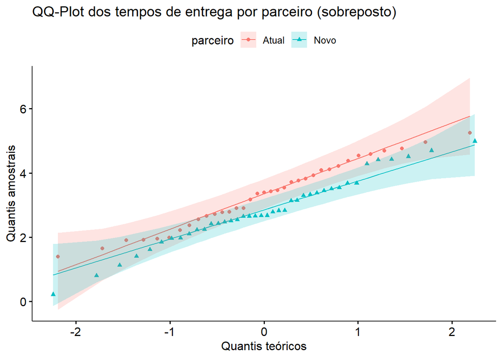

```r
# Gráfico quantile-quantile para verificar normalidade dos dados

ggqqplot(dados_entrega,
         x     = "tempo",
         color = "parceiro",
         shape = "parceiro") +
  labs(
    title = "QQ-Plot dos tempos de entrega por parceiro (sobreposto)",
    x     = "Quantis teóricos",
    y     = "Quantis amostrais"
  )
```

**b)**

```r
# Estimativa por intervalo de confiança para a diferença entre médias
res_diff <- t.test(
  tempo ~ parceiro,
  data      = dados_entrega,
  conf.level = 0.95
)
res_diff$conf.int
```

```
[1] -0.000512  0.962466
attr(,"conf.level")
[1] 0.95
```

**c)**

```r
# Rode o t-test e salve no objeto 'resultado_ttest'
resultado_ttest <- t.test(
  tempo ~ parceiro,
  data      = dados_entrega,
  conf.level = 0.95
)

# Agora você pode extrair as estimativas
media_atual <- resultado_ttest$estimate[1]
media_novo  <- resultado_ttest$estimate[2]

diferenca_estimada <- media_atual - media_novo

diferenca_estimada
```

```
mean in group Atual
              0.481
```

**d)**

Considerando que o 0 aparece no intervalo, não temos evidência significativa de que um dos parceiros tenha tempo médio de entrega maior que outro.